# Practical Machine Learning Course Project: Prediction Assignment Writeup

Catalina Barco Castillo

10/11/2020

*Background*

Using devices such as Jawbone Up, Nike FuelBand, and Fitbit it is now possible to collect a large amount of data about personal activity relatively inexpensively. These type of devices are part of the quantified self movement – a group of enthusiasts who take measurements about themselves regularly to improve their health, to find patterns in their behavior, or because they are tech geeks. One thing that people regularly do is quantify how much of a particular activity they do, but they rarely quantify how well they do it. In this project, your goal will be to use data from accelerometers on the belt, forearm, arm, and dumbell of 6 participants. They were asked to perform barbell lifts correctly and incorrectly in 5 different ways.

*Data*

The training data for this project are available here: https://d396qusza40orc.cloudfront.net/predmachlearn/pml-training.csv The test data are available here: https://d396qusza40orc.cloudfront.net/predmachlearn/pml-testing.csv The data for this project come from this source: http://web.archive.org/web/20161224072740/http:/groupware.les.inf.puc-rio.br/har.

*Preparation*

```r
library(caret)
```

```r
library(lattice)
library(rpart.plot)
library(rpart)
```

*The dataset*

```r
training_data <- read.csv('pml-training.csv', na.strings = c("NA", "#DIV/0!", ""))
test_data <- read.csv('pml-testing.csv', na.strings = c("NA", "#DIV/0!", ""))
```

*Training data has 19622 observations and 160 variables, while testing data provides 20 observation for 160 variables.*

```r
clean_column <- colSums(is.na(training_data))/nrow(training_data) < 0.95
clean_training_data <- training_data[,clean_column]
colSums(is.na(clean_training_data))/nrow(clean_training_data)
```

```
##                    X            user_name raw_timestamp_part_1
##                    0                    0                    0
## raw_timestamp_part_2       cvtd_timestamp           new_window
##                    0                    0                    0
##           num_window            roll_belt           pitch_belt
##                    0                    0                    0
##             yaw_belt     total_accel_belt         gyros_belt_x
##                    0                    0                    0
##         gyros_belt_y         gyros_belt_z         accel_belt_x
##                    0                    0                    0
##         accel_belt_y         accel_belt_z        magnet_belt_x
##                    0                    0                    0
##        magnet_belt_y        magnet_belt_z             roll_arm
##                    0                    0                    0
##            pitch_arm              yaw_arm      total_accel_arm
##                    0                    0                    0
##          gyros_arm_x          gyros_arm_y          gyros_arm_z
##                    0                    0                    0
##          accel_arm_x          accel_arm_y          accel_arm_z
##                    0                    0                    0
##         magnet_arm_x         magnet_arm_y         magnet_arm_z
##                    0                    0                    0
##        roll_dumbbell       pitch_dumbbell         yaw_dumbbell
##                    0                    0                    0
## total_accel_dumbbell     gyros_dumbbell_x     gyros_dumbbell_y
##                    0                    0                    0
##     gyros_dumbbell_z     accel_dumbbell_x     accel_dumbbell_y
##                    0                    0                    0
##     accel_dumbbell_z    magnet_dumbbell_x    magnet_dumbbell_y
##                    0                    0                    0
##    magnet_dumbbell_z         roll_forearm        pitch_forearm
##                    0                    0                    0
##          yaw_forearm  total_accel_forearm      gyros_forearm_x
##                    0                    0                    0
##      gyros_forearm_y      gyros_forearm_z      accel_forearm_x
##                    0                    0                    0
##      accel_forearm_y      accel_forearm_z     magnet_forearm_x
##                    0                    0                    0
##     magnet_forearm_y     magnet_forearm_z               classe
##                    0                    0                    0
```

```r
colSums(is.na(clean_training_data))
```

```
##                    X            user_name raw_timestamp_part_1
##                    0                    0                    0
## raw_timestamp_part_2       cvtd_timestamp           new_window
##                    0                    0                    0
##           num_window            roll_belt           pitch_belt
##                    0                    0                    0
##             yaw_belt     total_accel_belt         gyros_belt_x
##                    0                    0                    0
##         gyros_belt_y         gyros_belt_z         accel_belt_x
##                    0                    0                    0
##         accel_belt_y         accel_belt_z        magnet_belt_x
##                    0                    0                    0
##        magnet_belt_y        magnet_belt_z             roll_arm
##                    0                    0                    0
##            pitch_arm              yaw_arm      total_accel_arm
##                    0                    0                    0
##          gyros_arm_x          gyros_arm_y          gyros_arm_z
##                    0                    0                    0
##          accel_arm_x          accel_arm_y          accel_arm_z
##                    0                    0                    0
##         magnet_arm_x         magnet_arm_y         magnet_arm_z
##                    0                    0                    0
##        roll_dumbbell       pitch_dumbbell         yaw_dumbbell
##                    0                    0                    0
## total_accel_dumbbell     gyros_dumbbell_x     gyros_dumbbell_y
##                    0                    0                    0
##     gyros_dumbbell_z     accel_dumbbell_x     accel_dumbbell_y
##                    0                    0                    0
##     accel_dumbbell_z    magnet_dumbbell_x    magnet_dumbbell_y
##                    0                    0                    0
##    magnet_dumbbell_z         roll_forearm        pitch_forearm
##                    0                    0                    0
##          yaw_forearm  total_accel_forearm      gyros_forearm_x
##                    0                    0                    0
##      gyros_forearm_y      gyros_forearm_z      accel_forearm_x
##                    0                    0                    0
##      accel_forearm_y      accel_forearm_z     magnet_forearm_x
##                    0                    0                    0
##     magnet_forearm_y     magnet_forearm_z               classe
##                    0                    0                    0
```

*All missing values (NA) were removed*

```r
clean_training_data <- clean_training_data[,-c(1:7)]
clean_test_data <- test_data[,-c(1:7)]
```

*Columns from 1 to 7 did not provide relevant information to the model, hence, were removed*

```r
inTrainIndex <- createDataPartition(clean_training_data$classe, p=0.75)[[1]]
training_training_data <- clean_training_data[inTrainIndex,]
training_crossval_data <- clean_training_data[-inTrainIndex,]
```

*Creation of cross validation data set*

```r
allNames <- names(clean_training_data)
clean_test_data <- test_data[,allNames[1:52]]
```

*Decision tree*

```r
decision_tree <- train(classe ~., method='rpart', data=training_training_data)
decision_tree_prediction <- predict(decision_tree, training_crossval_data)
confusionMatrix(table(training_crossval_data$classe, decision_tree_prediction))
```

```
## Confusion Matrix and Statistics
##
##    decision_tree_prediction
##        A    B    C    D    E
##   A 1245   28  116    0    6
##   B  411  310  228    0    0
##   C  387   15  453    0    0
##   D  371  150  283    0    0
##   E  132  118  232    0  419
##
## Overall Statistics
##
##                Accuracy : 0.4949
##                  95% CI : (0.4808, 0.509)
##     No Information Rate : 0.5192
##     P-Value [Acc > NIR] : 0.9997
##
##                   Kappa : 0.34
##
##  Mcnemar's Test P-Value : NA
##
## Statistics by Class:
##
##                      Class: A Class: B Class: C Class: D Class: E
## Sensitivity            0.4890  0.49919  0.34527       NA  0.98588
## Specificity            0.9364  0.85081  0.88808   0.8361  0.89239
## Pos Pred Value         0.8925  0.32666  0.52982       NA  0.46504
## Neg Pred Value         0.6292  0.92137  0.78785       NA  0.99850
## Prevalence             0.5192  0.12663  0.26754   0.0000  0.08666
## Detection Rate         0.2539  0.06321  0.09237   0.0000  0.08544
## Detection Prevalence   0.2845  0.19352  0.17435   0.1639  0.18373
## Balanced Accuracy      0.7127  0.67500  0.61668       NA  0.93913
```

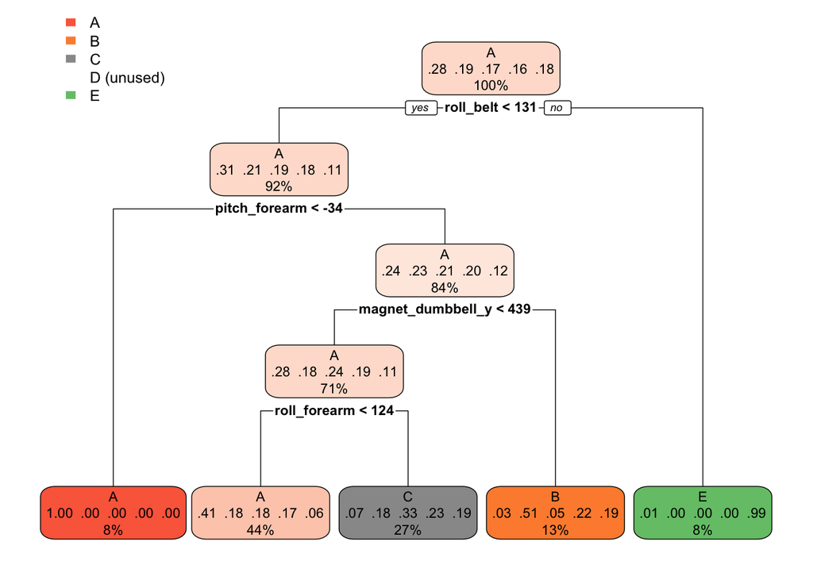

```r
rpart.plot(decision_tree$finalModel)
```

*Random forest*

```r
rfMod <- train(classe ~., method='rf', data=training_training_data, ntree=100)
rfPrediction <- predict(rfMod, training_crossval_data)
confusionMatrix(table(training_crossval_data$classe, rfPrediction))
```

```
## Confusion Matrix and Statistics
##
##    rfPrediction
##        A    B    C    D    E
##   A 1391    2    2    0    0
##   B    9  938    2    0    0
##   C    0    6  844    5    0
##   D    0    0   18  785    1
##   E    0    0    2    0  899
##
## Overall Statistics
##
##                Accuracy : 0.9904
##                  95% CI : (0.9873, 0.9929)
##     No Information Rate : 0.2855
##     P-Value [Acc > NIR] : < 2.2e-16
##
##                   Kappa : 0.9879
##
##  Mcnemar's Test P-Value : NA
##
## Statistics by Class:
##
##                      Class: A Class: B Class: C Class: D Class: E
## Sensitivity            0.9936   0.9915   0.9724   0.9937   0.9989
## Specificity            0.9989   0.9972   0.9973   0.9954   0.9995
## Pos Pred Value         0.9971   0.9884   0.9871   0.9764   0.9978
## Neg Pred Value         0.9974   0.9980   0.9941   0.9988   0.9998
## Prevalence             0.2855   0.1929   0.1770   0.1611   0.1835
## Detection Rate         0.2836   0.1913   0.1721   0.1601   0.1833
## Detection Prevalence   0.2845   0.1935   0.1743   0.1639   0.1837
## Balanced Accuracy      0.9962   0.9944   0.9848   0.9945   0.9992
```

*Prediction*

```r
predict(rfMod, clean_test_data)
```

```
##  [1] B A B A A E D B A A B C B A E E A B B B
## Levels: A B C D E
```